# GPT_Tweets

Shen Xie

2023/2/25

# 导入数据并进行数据预处理

– 读取数据

```r
Tweets_raw <- read.csv("ChatGPT_Tweets.csv", stringsAsFactors = FALSE, header = TRUE)
```

= 测试1：测试数据是否为UTF-8且不为空

**预处理数据：基本列情况分析**

```r
Tweets <- Tweets_raw %>%
  # 处理日期，由于GPT是22年11月推出（可选：我们选择滞后两个月的评论，评价会更加有意义）
  mutate(Date=as.Date(Date),
         year = as.numeric(substr(Date, 1, 4)),
         Month = as.numeric(substr(Date, 6, 7)),
         CreatDate = as.Date(UserCreated),
         Day_Gap = as.numeric(difftime( as.Date("2023-02-25"), Date, units = "days"))
         ) %>%
  # filter(year==2023) %>%
  # 筛选verified的用户，避免水军行为
  # filter(UserVerified=="TRUE")，数据量将大大减少，只剩下8738行
  # 通过Url生成ID列，同时注意去除空ID
  mutate(ID = str_extract(Url, "\\d{14}$")) %>%
  filter(!is.na(ID)) %>% # 此时剩下305399（223070）行数据
  # 去除文本中http:内容，然后匹配文本中#后面的内容，这相当于tag
  mutate(
    Tweet = gsub("https:.*", "", Tweet),
    Tweet = iconv(Tweet, to = 'UTF-8')
    ) %>%
  # 字数统计，多样性统计
  mutate(
    WC = str_count(Tweet,boundary("word")),
    Lexical_Diversity = map_dbl(str_extract_all(str_to_lower(Tweet), "\\w+"), ~ length(unique(.x)) / length(.x))
    ) %>%
  # 修改Likes和Retweets的格式
  mutate(
    Likes = as.numeric(Likes),
    Like_Perday = Likes/Day_Gap,
    Retweets = as.numeric(Retweets),
    Retweet_Perday = Retweets/Day_Gap
  ) %>%
  # 根据用户是否认证生成0-1
  mutate(User_Verified = ifelse(UserVerified=="TRUE",1,0)) %>%
  # 选出需要使用的列，同时安排顺序
  dplyr::select(ID, User, UserDescription, Location, CreatDate, User_Verified, UserFollowers, UserFriends, Tweet, Date, Month, Day_Gap, Likes, Like_Perday, Retweets, Retweet_Perday, WC, Lexical_Diversity)
```

= 测试2： 检验ID是否有重复

**预处理数据：识别身份特征**

```r
# 身份词典
NLP_D <- "\\b(NLProc|ACL|NAACL|CoNNL|COLING|EMNLP|NLP|nlp|TLE|SALLE|POS|Literal Annotation|Lemma|multilingual|fine tune|textual analysis|text analysis|GPT|GPT-3|GPT-3.5)\\b"

CSEEDS_D <- "\\b(CS|cs|computer science|EE|ee|Electrical Engineering|electrical engineering|DS|ds|data scientist|Data Scientist|data science|data analyst|ML|ml|DL|dl|machine learning|Machine Learning|Deep Learning|deep learning)\\b"

Research_D <- "\\b(PhD|phd|Researcher|researcher|Professor|professor|lab|laboratory|LAB|Lab|CTO|cto)\\b"

Expert_D <- "\\b(NLProc|ACL|NAACL|CoNNL|COLING|EMNLP|NLP|nlp|TLE|SALLE|POS|Literal Annotation|Lemma|multilingual|fine tune|textual analysis|text analysis|GPT|GPT-3|GPT-3.5|CS|cs|computer science|EE|ee|Electrical Engineering|electrical engineering|DS|ds|data scientist|Data Scientist|data science|data analyst|ML|ml|DL|dl|machine learning|Machine Learning|Deep Learning|deep learning|PhD|phd|Researcher|researcher|Professor|professor|lab|laboratory|LAB|Lab|CTO|cto)\\b"
```

```r
Tweets_User <- Tweets%>%
  filter(!is.na(UserDescription)) %>%
  mutate(
    UserDescription = iconv(UserDescription, to = 'UTF-8'),
    WC_Descrip = str_count(UserDescription,boundary("word")),
    ) %>%
  # 筛选Tweet有内容且用户有简介的部分
  filter(WC > 2) %>%
  filter(WC_Descrip > 1) %>% # 得到283132列
  # 分组并生成UserID
  group_by(User) %>%
  mutate(UserID = cur_group_id()) %>%
  ungroup() %>%
  # 抓取与NLP有关的介绍
  mutate(
    NLP = ifelse(str_detect(UserDescription, NLP_D), 1, 0),
    CSEEDS = ifelse(str_detect(UserDescription, CSEEDS_D), ifelse(NLP==0, 1, 0), 0),
    Research = ifelse(str_detect(UserDescription, Research_D), 1, 0),
    Expert = ifelse(str_detect(UserDescription, Expert_D), 1, 0)
  ) %>%
  dplyr::select(ID, UserID, User, UserDescription, WC_Descrip, Expert, NLP, CSEEDS, Research, Location, CreatDate, User_Verified, UserFollowers, UserFriends, Tweet, Date, Month, Day_Gap, Likes, Like_Perday, Retweets, Retweet_Perday, WC, Lexical_Diversity)
```

= 测试3：检验User是否有多发——有，可以考虑情绪是否存在变化

```r
Tweets_User %>%
  group_by(UserID) %>%
  mutate(n = n()) %>%
  filter(n>1)
```

```
## # A tibble: 192,449 × 25
## # Groups:   UserID [39,966]
##    ID       UserID User  UserDescription WC_Descrip Expert   NLP CSEEDS Research
##    <chr>     <int> <chr> <chr>                <int>  <dbl> <dbl>  <dbl>    <dbl>
##  1 2807815… 129379 your… "\U0001f913 Pr…         16      0     0      0        0
##  2 2790540…  76798 meta… "Metaverse Wor…         22      0     0      0        0
##  3 2732355…  46329 glob… "China's natio…         13      0     0      0        0
##  4 2731361…    249 _atu… "building http…          4      0     0      0        0
##  5 2711677…  16461 Bern… "\U0001f4d6 In…         16      0     0      0        0
##  6 2699804…  77593 Migh… "We offer an e…         20      0     0      0        0
##  7 2696233…  78286 mink… "\U0001f4cdFlo…          2      0     0      0        0
##  8 2691507…  54772 Inks… "Installing kn…         15      0     0      0        0
##  9 2673968…  30493 Data… "∙ Developer \…         13      0     0      0        0
## 10 2673081… 127189 wima… "Now or Never"           3      0     0      0        0
## # … with 192,439 more rows, and 16 more variables: Location <chr>,
## #   CreatDate <date>, User_Verified <dbl>, UserFollowers <int>,
## #   UserFriends <int>, Tweet <chr>, Date <date>, Month <dbl>, Day_Gap <dbl>,
## #   Likes <dbl>, Like_Perday <dbl>, Retweets <dbl>, Retweet_Perday <dbl>,
## #   WC <int>, Lexical_Diversity <dbl>, n <int>
```

= 测试4：检验UserID是否有重复

```r
Tweets_User %>%
  group_by(UserID, User) %>%
  mutate(n = n()) %>%
  filter(n>1)
```

```
## # A tibble: 192,449 × 25
## # Groups:   UserID, User [39,966]
##    ID       UserID User  UserDescription WC_Descrip Expert   NLP CSEEDS Research
##    <chr>     <int> <chr> <chr>                <int>  <dbl> <dbl>  <dbl>    <dbl>
##  1 2807815… 129379 your… "\U0001f913 Pr…         16      0     0      0        0
##  2 2790540…  76798 meta… "Metaverse Wor…         22      0     0      0        0
##  3 2732355…  46329 glob… "China's natio…         13      0     0      0        0
##  4 2731361…    249 _atu… "building http…          4      0     0      0        0
##  5 2711677…  16461 Bern… "\U0001f4d6 In…         16      0     0      0        0
##  6 2699804…  77593 Migh… "We offer an e…         20      0     0      0        0
##  7 2696233…  78286 mink… "\U0001f4cdFlo…          2      0     0      0        0
##  8 2691507…  54772 Inks… "Installing kn…         15      0     0      0        0
##  9 2673968…  30493 Data… "∙ Developer \…         13      0     0      0        0
## 10 2673081… 127189 wima… "Now or Never"           3      0     0      0        0
## # … with 192,439 more rows, and 16 more variables: Location <chr>,
## #   CreatDate <date>, User_Verified <dbl>, UserFollowers <int>,
## #   UserFriends <int>, Tweet <chr>, Date <date>, Month <dbl>, Day_Gap <dbl>,
## #   Likes <dbl>, Like_Perday <dbl>, Retweets <dbl>, Retweet_Perday <dbl>,
## #   WC <int>, Lexical_Diversity <dbl>, n <int>
```

```r
# 与测试3输出结果一致，说明没问题！
```

= 测验5 检测有多少用户生成的内容

```r
Tweets_User %>%
  filter(Expert == 1) %>%
  # 有26008行
  group_by(UserID)
```

```
## # A tibble: 26,008 × 24
## # Groups:   UserID [9,470]
##    ID       UserID User  UserDescription WC_Descrip Expert   NLP CSEEDS Research
##    <chr>     <int> <chr> <chr>                <int>  <dbl> <dbl>  <dbl>    <dbl>
##  1 2603917…  49341 Hass… "Data Scientis…          4      1     0      1        1
##  2 2408611…   8999 AMLD… "Applied Machi…         15      1     0      1        0
##  3 2296074…    980 _peb… "Data | Privac…          4      1     1      0        0
##  4 2166612…  21470 Cape… "CTO | Gin Ent…         19      1     0      0        1
##  5 1964428…  90484 pedr… "CTO at Micros…          7      1     0      0        1
##  6 1196949…  48825 haoz… "Incoming Assi…         10      1     0      1        1
##  7 0730360…  24444 chug… "Associate Pro…         20      1     0      0        1
##  8 0572044…  18610 bobe… "PhD in indust…         11      1     0      0        1
##  9 0400748…  85499 Niti… "#Datascience …         15      1     0      1        0
## 10 9941663…  87749 Omka… "Executive Cha…         21      1     0      0        1
## # … with 25,998 more rows, and 15 more variables: Location <chr>,
## #   CreatDate <date>, User_Verified <dbl>, UserFollowers <int>,
## #   UserFriends <int>, Tweet <chr>, Date <date>, Month <dbl>, Day_Gap <dbl>,
## #   Likes <dbl>, Like_Perday <dbl>, Retweets <dbl>, Retweet_Perday <dbl>,
## #   WC <int>, Lexical_Diversity <dbl>
```

```r
  # 来自于9470位用户

Tweets_User %>%
  filter(NLP == 1) %>%
  # 有2698行，太少了
  group_by(UserID)
```

```
## # A tibble: 2,698 × 24
## # Groups:   UserID [641]
##    ID       UserID User  UserDescription WC_Descrip Expert   NLP CSEEDS Research
##    <chr>     <int> <chr> <chr>                <int>  <dbl> <dbl>  <dbl>    <dbl>
##  1 2296074…    980 _peb… "Data | Privac…          4      1     1      0        0
##  2 6203584…  94877 R_Fr… "Electrical an…         19      1     1      0        0
##  3 5688432…  25157 Clou… "https://t.co/…         28      1     1      0        0
##  4 5687976…  25157 Clou… "https://t.co/…         28      1     1      0        0
##  5 5435029…   8811 amia… "American Medi…         10      1     1      0        0
##  6 6120952…  23230 Chat… "Tech enthusia…         23      1     1      0        0
##  7 5756588…  42222 FinS… "We are buildi…         19      1     1      0        0
##  8 4313373…  14537 B__A… "Exploring the…         24      1     1      0        0
##  9 3100660…  23230 Chat… "Tech enthusia…         23      1     1      0        0
## 10 1259889… 121621 tyle… "Transforming …         20      1     1      0        0
## # … with 2,688 more rows, and 15 more variables: Location <chr>,
## #   CreatDate <date>, User_Verified <dbl>, UserFollowers <int>,
## #   UserFriends <int>, Tweet <chr>, Date <date>, Month <dbl>, Day_Gap <dbl>,
## #   Likes <dbl>, Like_Perday <dbl>, Retweets <dbl>, Retweet_Perday <dbl>,
## #   WC <int>, Lexical_Diversity <dbl>
```

```r
  # 来自于641位用户

Tweets_User %>%
  filter(CSEEDS == 1) %>%
  # 有11143行
  group_by(UserID)
```

```
## # A tibble: 11,143 × 24
## # Groups:   UserID [3,153]
##    ID       UserID User  UserDescription WC_Descrip Expert   NLP CSEEDS Research
##    <chr>     <int> <chr> <chr>                <int>  <dbl> <dbl>  <dbl>    <dbl>
##  1 2603917…  49341 Hass… "Data Scientis…          4      1     0      1        1
##  2 2408611…   8999 AMLD… "Applied Machi…         15      1     0      1        0
##  3 1196949…  48825 haoz… "Incoming Assi…         10      1     0      1        1
##  4 0400748…  85499 Niti… "#Datascience …         15      1     0      1        0
##  5 9259084… 112176 Sura… "CEO / MD, Sur…          9      1     0      1        0
##  6 9130339…  66910 krri… "building http…         22      1     0      1        0
##  7 6046875…  25208 clou… "Finalist Micr…         21      1     0      1        0
##  8 5661317… 112698 Syed… "#FamilyFirst …         11      1     0      1        0
##  9 4731987…   6081 aipl… "To support th…         25      1     0      1        0
## 10 4574438…  46636 goku… "Data Analyst …         16      1     0      1        0
## # … with 11,133 more rows, and 15 more variables: Location <chr>,
## #   CreatDate <date>, User_Verified <dbl>, UserFollowers <int>,
## #   UserFriends <int>, Tweet <chr>, Date <date>, Month <dbl>, Day_Gap <dbl>,
## #   Likes <dbl>, Like_Perday <dbl>, Retweets <dbl>, Retweet_Perday <dbl>,
## #   WC <int>, Lexical_Diversity <dbl>
```

```r
  # 来自于3153位用户

Tweets_User %>%
  filter(Research == 1) %>%
  # 有14952行
  group_by(UserID)
```

```
## # A tibble: 14,952 × 24
## # Groups:   UserID [6,343]
##    ID       UserID User  UserDescription WC_Descrip Expert   NLP CSEEDS Research
##    <chr>     <int> <chr> <chr>                <int>  <dbl> <dbl>  <dbl>    <dbl>
##  1 2603917…  49341 Hass… "Data Scientis…          4      1     0      1        1
##  2 2166612…  21470 Cape… "CTO | Gin Ent…         19      1     0      0        1
##  3 1964428…  90484 pedr… "CTO at Micros…          7      1     0      0        1
##  4 1196949…  48825 haoz… "Incoming Assi…         10      1     0      1        1
##  5 0730360…  24444 chug… "Associate Pro…         20      1     0      0        1
##  6 0572044…  18610 bobe… "PhD in indust…         11      1     0      0        1
##  7 9941663…  87749 Omka… "Executive Cha…         21      1     0      0        1
##  8 8838886…  65738 King… "CTO Coach - A…         14      1     0      0        1
##  9 8819092… 107389 Sino… "FICC investor…         17      1     0      0        1
## 10 8429239…  58241 Javi… "Assistant Pro…         14      1     0      0        1
## # … with 14,942 more rows, and 15 more variables: Location <chr>,
## #   CreatDate <date>, User_Verified <dbl>, UserFollowers <int>,
## #   UserFriends <int>, Tweet <chr>, Date <date>, Month <dbl>, Day_Gap <dbl>,
## #   Likes <dbl>, Like_Perday <dbl>, Retweets <dbl>, Retweet_Perday <dbl>,
## #   WC <int>, Lexical_Diversity <dbl>
```

```r
  # 来自于6343位用户
```

**预处理数据：推文层面分析**

DayGap: 截止爬取时间2023.2.25，推文发出时间； LikePerD：用于表示内容认同度，平均每天的获赞量； RetweetPerD：用于表示传播影响力，平均每天的转推量；

```r
mean(Tweets_User$Like_Perday)
```

```
## [1] 0.3165904
```

```r
mean(Tweets_User$Retweet_Perday)
```

```
## [1] 0.08756077
```

感兴趣的是推文的质量与影响力，因此选取大于0的部分

```r
Tweets_User2 <- Tweets_User %>%
  filter(Like_Perday>0) %>%
  filter(Retweet_Perday>0)
```

= 测验6 检测在筛选后有多少NLP用户生成的内容

```r
Tweets_User2 %>%
  filter(Expert == 1) %>%
  # 有6684行
  group_by(UserID)
```

```
## # A tibble: 6,684 × 24
## # Groups:   UserID [3,244]
##    ID       UserID User  UserDescription WC_Descrip Expert   NLP CSEEDS Research
##    <chr>     <int> <chr> <chr>                <int>  <dbl> <dbl>  <dbl>    <dbl>
##  1 2166612…  21470 Cape… "CTO | Gin Ent…         19      1     0      0        1
##  2 9941663…  87749 Omka… "Executive Cha…         21      1     0      0        1
##  3 8819092… 107389 Sino… "FICC investor…         17      1     0      0        1
##  4 6046875…  25208 clou… "Finalist Micr…         21      1     0      1        0
##  5 5435029…   8811 amia… "American Medi…         10      1     1      0        0
##  6 2183344… 129052 yjad… "Exploring the…         21      1     0      0        1
##  7 2014086… 122306 UniM… "Uni Matrix Z …         14      1     0      1        0
##  8 1649527…  62721 Juli… "Jonathan’s Da…         19      1     0      0        1
##  9 0779872… 122872 UTS_… "Connected Int…         12      1     0      1        0
## 10 9978101…  39167 enil… "Top #Influenc…         23      1     0      1        0
## # … with 6,674 more rows, and 15 more variables: Location <chr>,
## #   CreatDate <date>, User_Verified <dbl>, UserFollowers <int>,
## #   UserFriends <int>, Tweet <chr>, Date <date>, Month <dbl>, Day_Gap <dbl>,
## #   Likes <dbl>, Like_Perday <dbl>, Retweets <dbl>, Retweet_Perday <dbl>,
## #   WC <int>, Lexical_Diversity <dbl>
```

```r
  # 来自于3244位用户

Tweets_User2 %>%
  filter(NLP == 1) %>%
  # 有809行，太少了
  group_by(UserID)
```

```
## # A tibble: 809 × 24
## # Groups:   UserID [254]
##    ID       UserID User  UserDescription WC_Descrip Expert   NLP CSEEDS Research
##    <chr>     <int> <chr> <chr>                <int>  <dbl> <dbl>  <dbl>    <dbl>
##  1 5435029…   8811 amia… "American Medi…         10      1     1      0        0
##  2 9836179… 109177 Sout… "Denver's Trus…         22      1     1      0        0
##  3 9628818…  75393 mayu… "I write tweet…         10      1     1      0        0
##  4 7874244…   5931 AIFl… "Telegram: htt…         17      1     1      0        0
##  5 4030740…  23230 Chat… "Tech enthusia…         23      1     1      0        0
##  6 3843156…  26659 CorT… "CorTexT platf…         14      1     1      0        0
##  7 3765229…  95530 raje… "Blockchain, O…         19      1     1      0        0
##  8 7009618…   5931 AIFl… "Telegram: htt…         17      1     1      0        0
##  9 8411444…   5931 AIFl… "Telegram: htt…         17      1     1      0        0
## 10 3729992…  60982 John… "I'm a technol…         16      1     1      0        0
## # … with 799 more rows, and 15 more variables: Location <chr>,
## #   CreatDate <date>, User_Verified <dbl>, UserFollowers <int>,
## #   UserFriends <int>, Tweet <chr>, Date <date>, Month <dbl>, Day_Gap <dbl>,
## #   Likes <dbl>, Like_Perday <dbl>, Retweets <dbl>, Retweet_Perday <dbl>,
## #   WC <int>, Lexical_Diversity <dbl>
```

```r
  # 来自于254位用户

Tweets_User2 %>%
  filter(CSEEDS == 1) %>%
  # 有2548行
  group_by(UserID)
```

```
## # A tibble: 2,548 × 24
## # Groups:   UserID [978]
##    ID       UserID User  UserDescription WC_Descrip Expert   NLP CSEEDS Research
##    <chr>     <int> <chr> <chr>                <int>  <dbl> <dbl>  <dbl>    <dbl>
##  1 6046875…  25208 clou… "Finalist Micr…         21      1     0      1        0
##  2 2014086… 122306 UniM… "Uni Matrix Z …         14      1     0      1        0
##  3 0779872… 122872 UTS_… "Connected Int…         12      1     0      1        0
##  4 9978101…  39167 enil… "Top #Influenc…         23      1     0      1        0
##  5 9976877…  39167 enil… "Top #Influenc…         23      1     0      1        0
##  6 8678677…   9216 AnaB… "Senior Data S…         16      1     0      1        0
##  7 7678535…  18652 BobT… "Computational…         21      1     0      1        0
##  8 6727766… 107510 Site… "#SEO 2004 // …         20      1     0      1        0
##  9 1898759…  80694 mril… "Professor (Ec…         16      1     0      1        1
## 10 1818375…  22221 Cbsa… "Coding But St…         26      1     0      1        1
## # … with 2,538 more rows, and 15 more variables: Location <chr>,
## #   CreatDate <date>, User_Verified <dbl>, UserFollowers <int>,
## #   UserFriends <int>, Tweet <chr>, Date <date>, Month <dbl>, Day_Gap <dbl>,
## #   Likes <dbl>, Like_Perday <dbl>, Retweets <dbl>, Retweet_Perday <dbl>,
## #   WC <int>, Lexical_Diversity <dbl>
```

```r
  # 来自于978位用户

Tweets_User2 %>%
  filter(Research == 1) %>%
  # 有3830行
  group_by(UserID)
```

```
## # A tibble: 3,830 × 24
## # Groups:   UserID [2,276]
##    ID       UserID User  UserDescription WC_Descrip Expert   NLP CSEEDS Research
##    <chr>     <int> <chr> <chr>                <int>  <dbl> <dbl>  <dbl>    <dbl>
##  1 2166612…  21470 Cape… "CTO | Gin Ent…         19      1     0      0        1
##  2 9941663…  87749 Omka… "Executive Cha…         21      1     0      0        1
##  3 8819092… 107389 Sino… "FICC investor…         17      1     0      0        1
##  4 2183344… 129052 yjad… "Exploring the…         21      1     0      0        1
##  5 1649527…  62721 Juli… "Jonathan’s Da…         19      1     0      0        1
##  6 8434439…  41512 Faus… "Committed pro…         24      1     0      0        1
##  7 7259702…   7863 Alin… "Computational…         12      1     0      0        1
##  8 6661009…  35632 DrEs… "Professor Eme…         20      1     0      0        1
##  9 6585629…  24578 cing… "Associate Pro…         16      1     0      0        1
## 10 6568451…  35632 DrEs… "Professor Eme…         20      1     0      0        1
## # … with 3,820 more rows, and 15 more variables: Location <chr>,
## #   CreatDate <date>, User_Verified <dbl>, UserFollowers <int>,
## #   UserFriends <int>, Tweet <chr>, Date <date>, Month <dbl>, Day_Gap <dbl>,
## #   Likes <dbl>, Like_Perday <dbl>, Retweets <dbl>, Retweet_Perday <dbl>,
## #   WC <int>, Lexical_Diversity <dbl>
```

```r
  # 来自于2276位用户
```

```r
mean(Tweets_User2$Like_Perday)
```

```
## [1] 1.242374
```

```r
mean(Tweets_User2$Retweet_Perday)
```

```
## [1] 0.3830554
```

```r
# 提出疑问？用中位数好还是？
Tweets_User2 <- Tweets_User2 %>%
  mutate(
    LikeType = ifelse(Like_Perday>=1.5*mean(Like_Perday), "MostLike",
                      ifelse(Like_Perday<0.5*mean(Like_Perday),"LeastLike", "MedianLike")),
    RetweetType = ifelse(Retweet_Perday>=1.5*mean(Retweet_Perday), "MostRetweet",
                      ifelse(Retweet_Perday<0.5*mean(Retweet_Perday),"LeastRetweet", "MedianRetweet")),
    Most_Popular = ifelse(LikeType=="MostLike", ifelse(RetweetType=="MostRetweet",1,0),0)
    )
```

= 测验7 查看处理后变量的基本情况

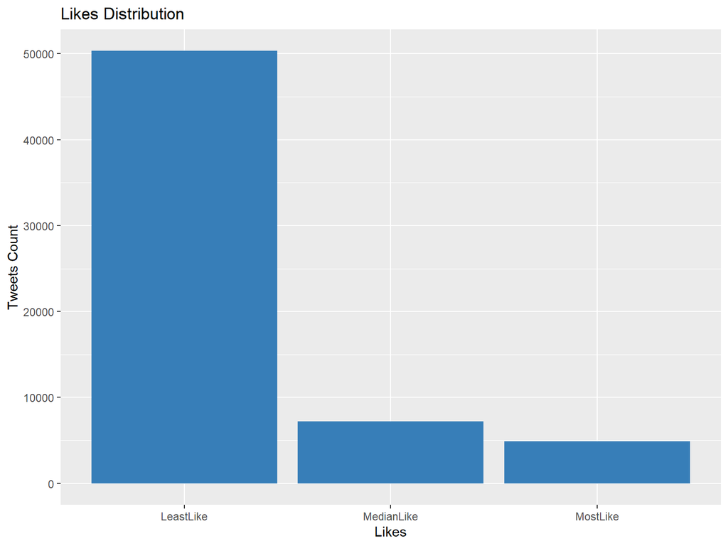

```r
Tweets_User2 %>%
  ggplot(aes(x = LikeType)) +
  #geom_freqpoly(binwidth = 5) +
  geom_bar(fill = brewer.pal(6, "Set1")[2]) +
  labs(title = "Likes Distribution", x = "Likes", y = "Tweets Count")
```

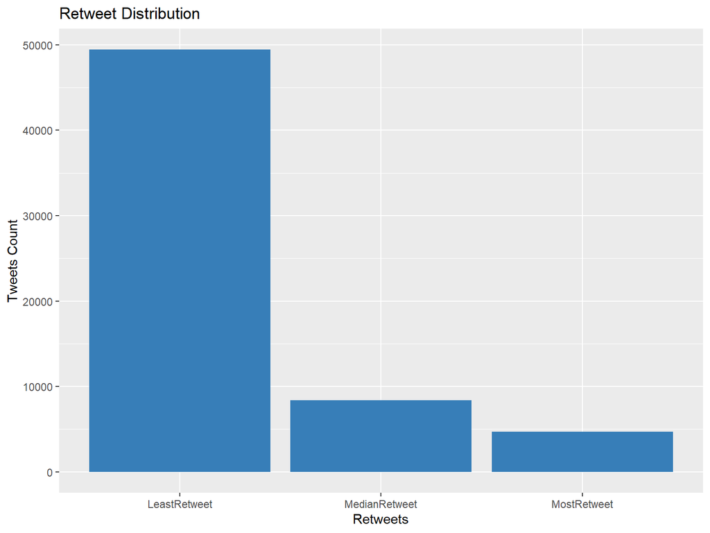

```r
Tweets_User2 %>%
  ggplot(aes(x = RetweetType)) +
  #geom_freqpoly(binwidth = 5) +
  geom_bar(fill = brewer.pal(6, "Set1")[2]) +
  labs(title = "Retweet Distribution", x = "Retweets", y = "Tweets Count")
```

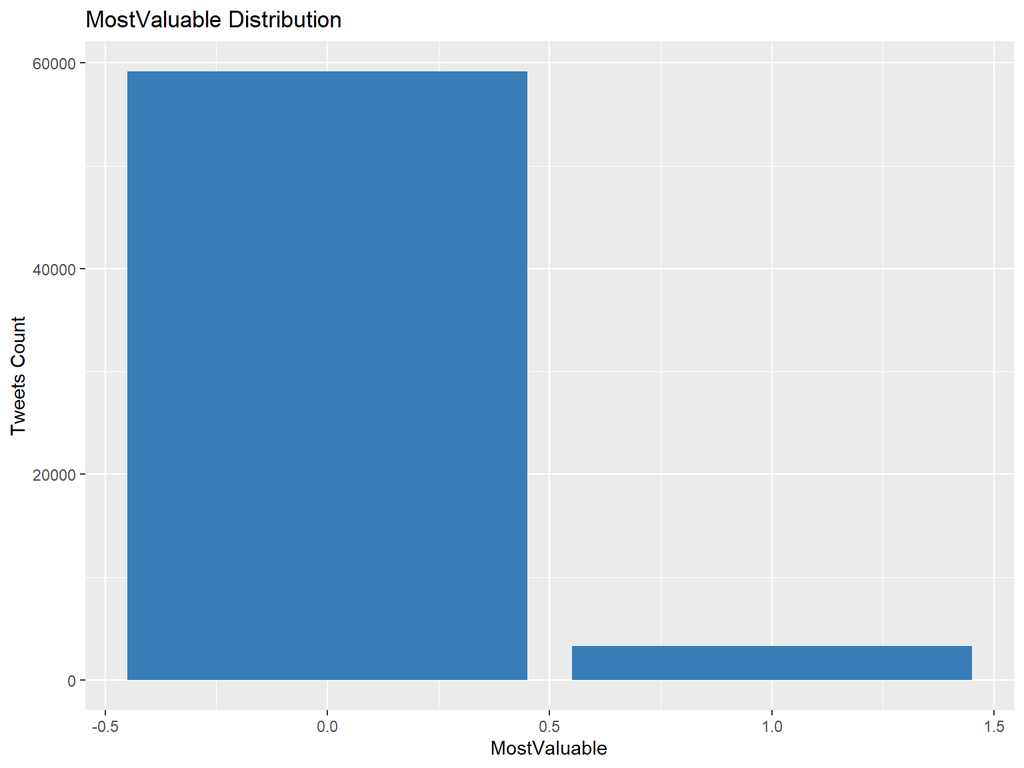

```r
Tweets_User2 %>%
  ggplot(aes(x = Most_Popular)) +
  #geom_freqpoly(binwidth = 5) +
  geom_bar(fill = brewer.pal(6, "Set1")[2]) +
  labs(title = "MostValuable Distribution", x = "MostValuable", y = "Tweets Count")
```

= 测验8 查看处理后变量的分组情况

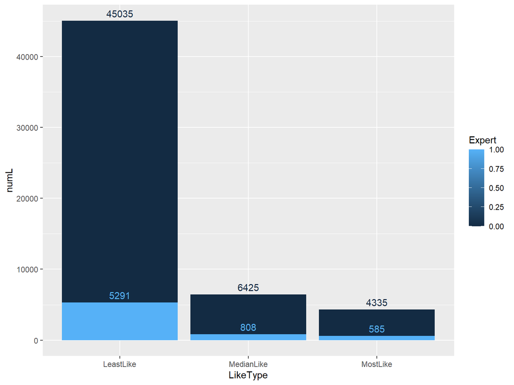

```r
Tweets_Graph1 <- Tweets_User2 %>%
  group_by(LikeType, Expert) %>%
  mutate(numL = n()) %>%
  slice(1) %>%
  ungroup() %>%
  dplyr::select(Expert, LikeType, numL)

Tweets_Graph1 %>%
  ggplot(aes(x = LikeType, y = numL, fill = Expert)) +
   geom_bar(stat = "identity", position = position_dodge(width = 0.7)) +
  geom_text(aes(label = numL,  color = Expert), position = position_dodge(width = 0.8), vjust = -0.5)
```

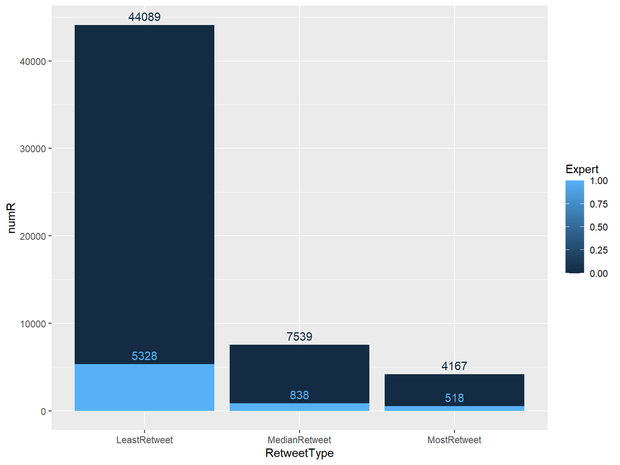

```r
Tweets_Graph2 <- Tweets_User2 %>%
  group_by(RetweetType, Expert) %>%
  mutate(numR = n()) %>%
  slice(1) %>%
  ungroup() %>%
  dplyr::select(Expert, RetweetType, numR)

Tweets_Graph2 %>%
  ggplot(aes(x = RetweetType, y = numR, fill = Expert)) +
   geom_bar(stat = "identity", position = position_dodge(width = 0.7)) +
  geom_text(aes(label = numR, color = Expert), position = position_dodge(width = 0.8), vjust = -0.5)
```

```r
remove(Tweets_Graph1)
remove(Tweets_Graph2)
```

= 测验9 箱形图探究

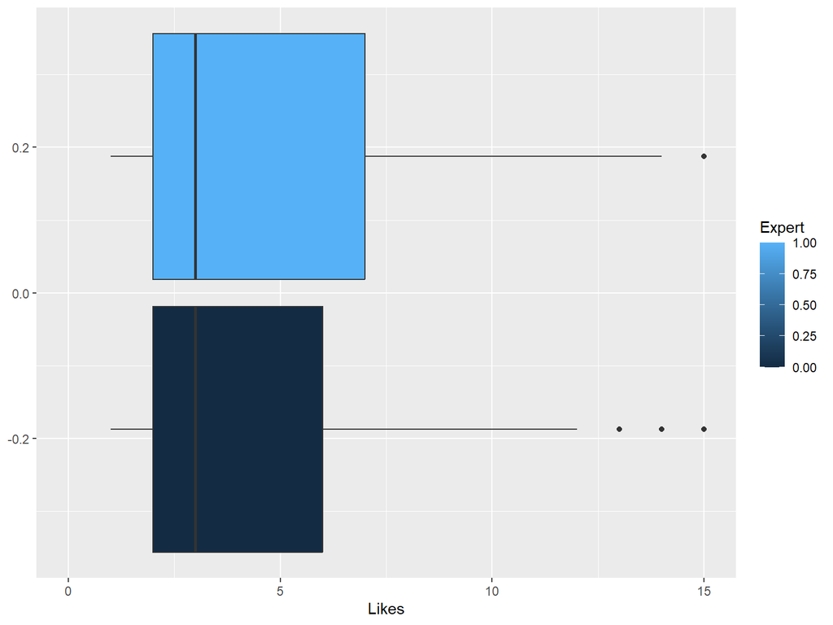

```r
Tweets_User2 %>%
  ggplot(aes(x = Likes, group = Expert, fill = Expert)) +
  geom_boxplot()  +
  xlim(0, 15)
```

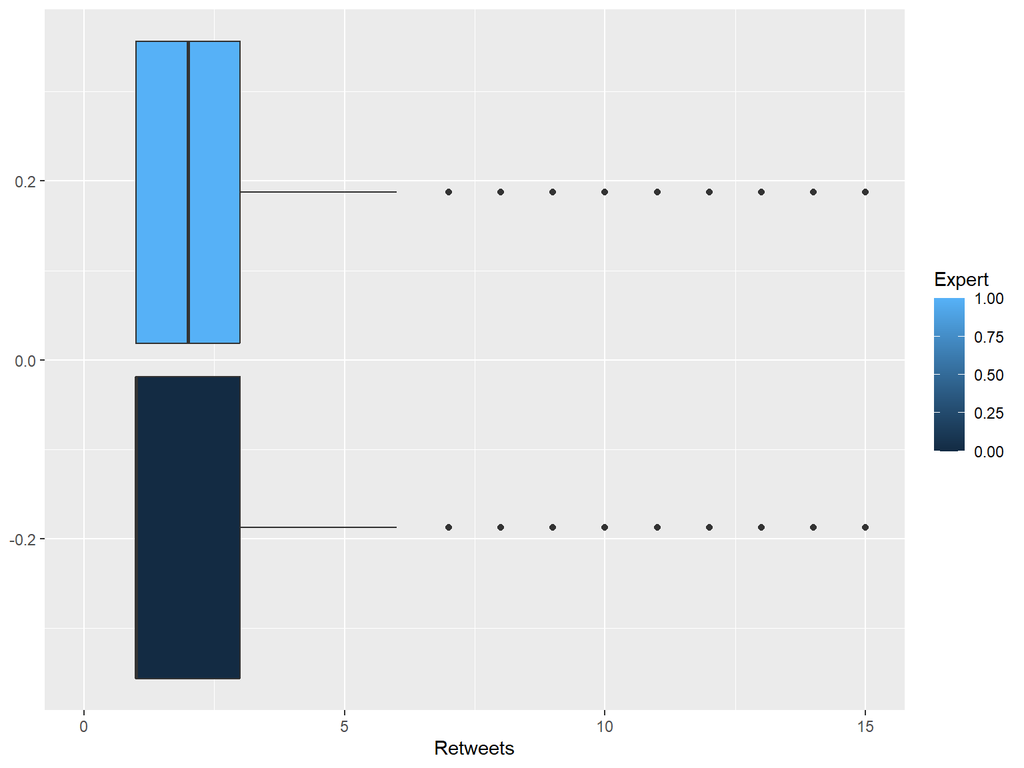

```r
Tweets_User2 %>%
  ggplot(aes(x = Retweets, group = Expert, fill = Expert)) +
  geom_boxplot() +
  xlim(0, 15)
```

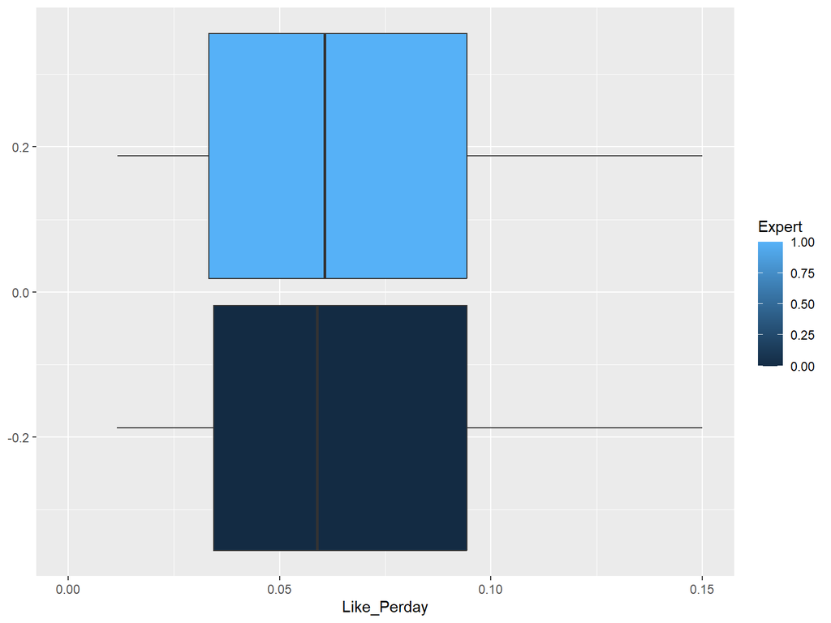

```r
Tweets_User2 %>%
  ggplot(aes(x = Like_Perday, group = Expert, fill = Expert)) +
  geom_boxplot() +
  xlim(0, 0.15)
```

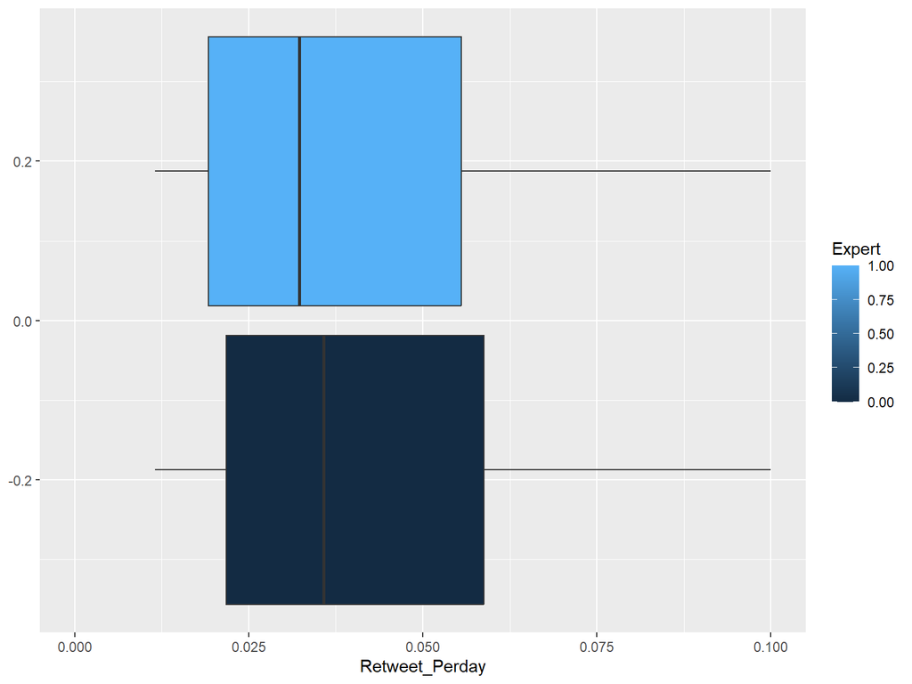

```r
Tweets_User2 %>%
  ggplot(aes(x = Retweet_Perday, group = Expert, fill = Expert)) +
  geom_boxplot() +
  xlim(0, 0.1)
```

# 可视化探究——基本信息展示

**1. 评论中单词个数的分布**

```r
summary(Tweets_User2$WC)
```

```
##    Min. 1st Qu.  Median    Mean 3rd Qu.    Max.
##    3.00   13.00   24.00   24.72   36.00   87.00
```

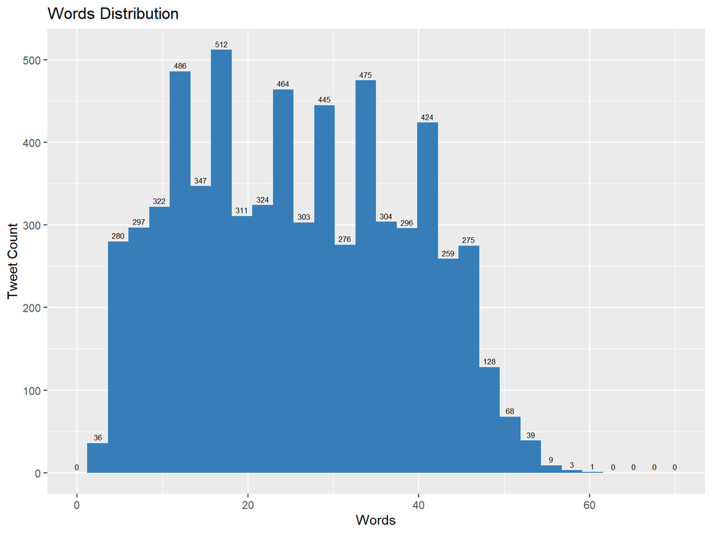

```r
Tweets_User2%>%
  filter(Expert==1) %>%
  ggplot(aes(x = WC)) +
  #geom_freqpoly(binwidth = 5) +
  geom_histogram(fill = brewer.pal(6, "Set1")[2]) +
  labs(title = "Words Distribution", x = "Words", y = "Tweet Count") +
  xlim(0,70) +
  stat_bin(aes(label = ..count..), geom = "text", vjust = -0.5, size = 2.2)
```

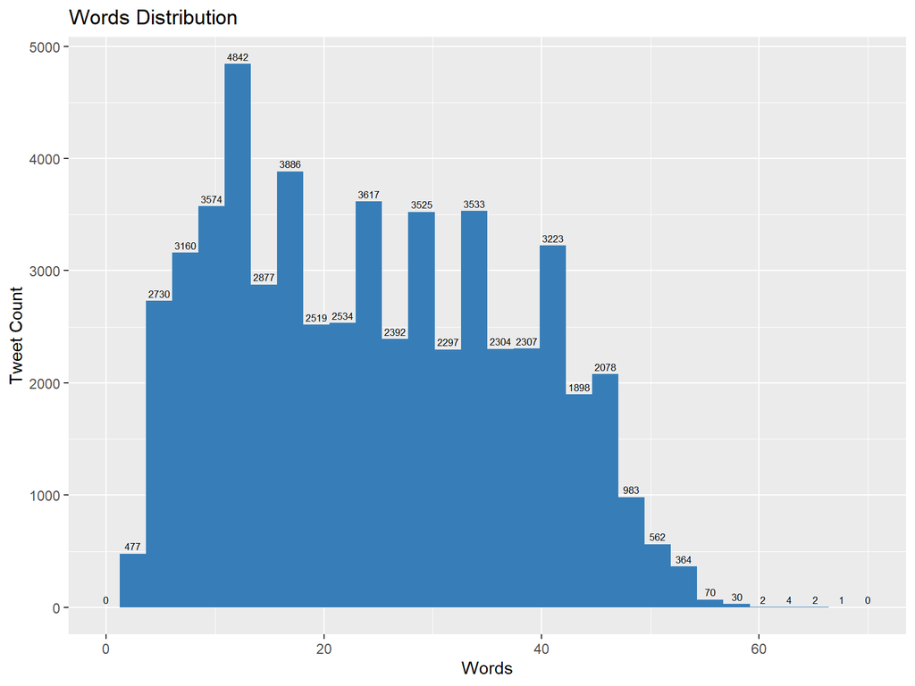

```r
Tweets_User2%>%
  filter(Expert==0) %>%
  ggplot(aes(x = WC)) +
  #geom_freqpoly(binwidth = 5) +
  geom_histogram(fill = brewer.pal(6, "Set1")[2]) +
  labs(title = "Words Distribution", x = "Words", y = "Tweet Count") +
  xlim(0,70) +
  stat_bin(aes(label = ..count..), geom = "text", vjust = -0.5, size = 2.2)
```

**2. 随着时间变化评论数量变化**

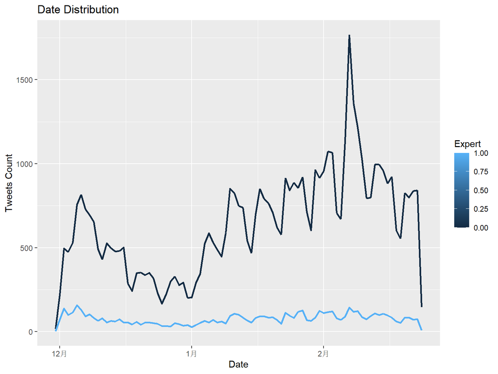

```r
Tweets_User2 %>%
  group_by(Date, Expert) %>%
  mutate(Num = n()) %>%
  ungroup() %>%
  ggplot(aes(x = Date, y = Num, group = Expert, color = Expert)) +
  geom_line(size = 1) +
  labs(title = "Date Distribution", x = "Date", y = "Tweets Count")
```

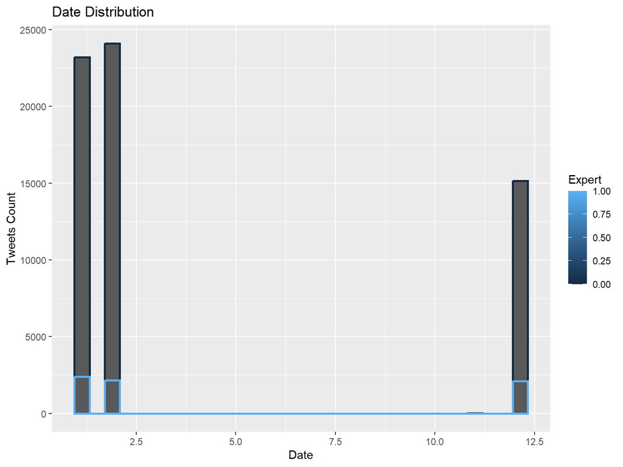

```r
Tweets_User2 %>%
  ggplot(aes(x = Month, group = Expert, color = Expert)) +
  geom_histogram(size = 1) +
  labs(title = "Date Distribution", x = "Date", y = "Tweets Count")
```

专家具有持续关注性！

**3. 查看点赞以及转推数量，参考上一节讲解的内容** 参考上一节讲解的内容。

# 对文本进行处理

**1.文本预处理**

首先得到基础的语料库，然后进行标准化操作，并生成DF：

```r
# 方法：参考quanteda资料，使用corpus的方法生成，更有利于处理（ref1:https://quanteda.io/articles/pkgdown/quickstart_cn.html；ref2:https://zhuanlan.zhihu.com/p/439456688）

# 去除文本中的Emoji符号
Tweet_noemoji <- gsub("[\U0001F600-\U0001F64F\U0001F300-\U0001F5FF\U0001F680-\U0001F6FF\U0001F1E0-\U0001F1FF]", "", Tweets_User2$Tweet, perl = TRUE)
# Des_noemoji <- gsub("[\U0001F600-\U0001F64F\U0001F300-\U0001F5FF\U0001F680-\U0001F6FF\U0001F1E0-\U0001F1FF]", "", Tweets$UserDescription, perl = TRUE)


# 生成语料库
Tweet_corpus <- corpus(Tweet_noemoji)
# Des_corpus <- corpus(Des_noemoji)
```

**2.可读性分析与情感分析**

使用quanteda.sentiment生成情感分析的变量。由于两种函数所包含的共同词典仅有nrc词典，所以均采用nrc词典进行情感提取

```r
Tweets_User3 <- Tweets_User2 %>%
  mutate(
    Readability = textstat_readability(Tweet_corpus, measure = "Flesch.Kincaid")$Flesch.Kincaid,
    Sentiment = as_tibble(textstat_polarity(Tweet_corpus, dictionary = data_dictionary_NRC))$sentiment
  )
```

== 可选：情感分析使用的是syuzhet包的函数，但是运行速度会很慢

- 可视化操作：对于文本可读性

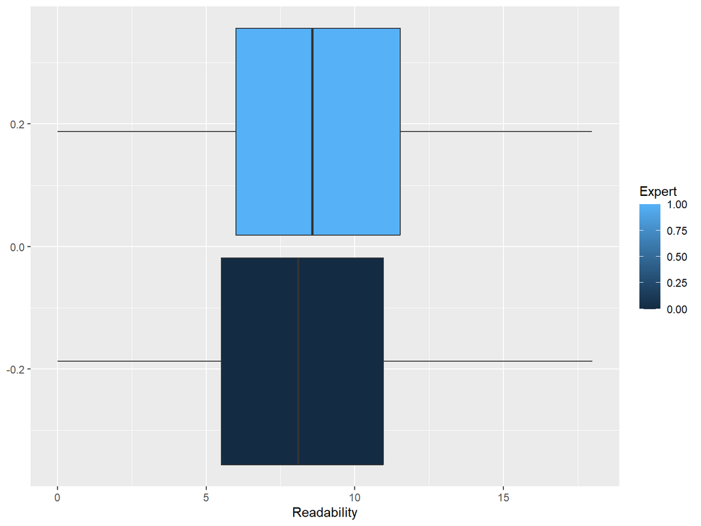

```r
Tweets_User3 %>%
  ggplot(aes(x = Readability, group = Expert, fill = Expert)) +
  geom_boxplot() +
  xlim(0, 18)
```

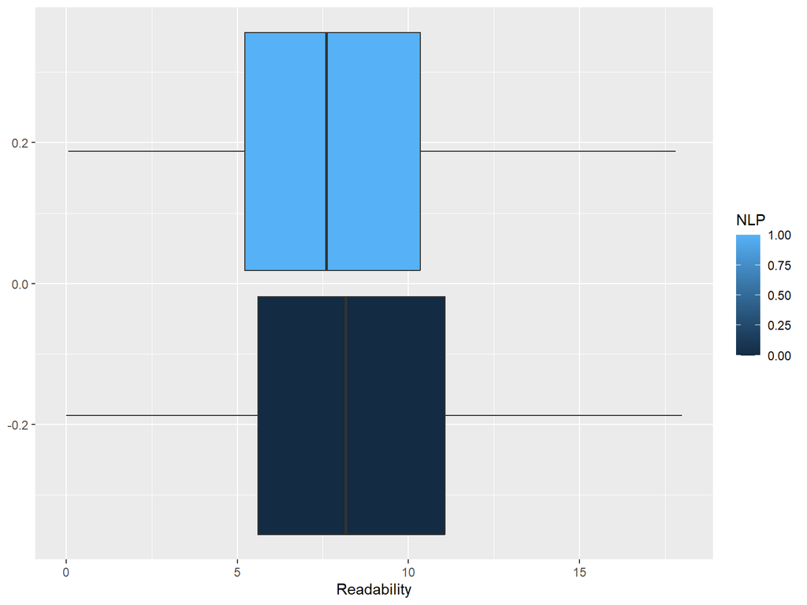

```r
Tweets_User3 %>%
  ggplot(aes(x = Readability, group = NLP, fill = NLP)) +
  geom_boxplot() +
  xlim(0, 18)
```

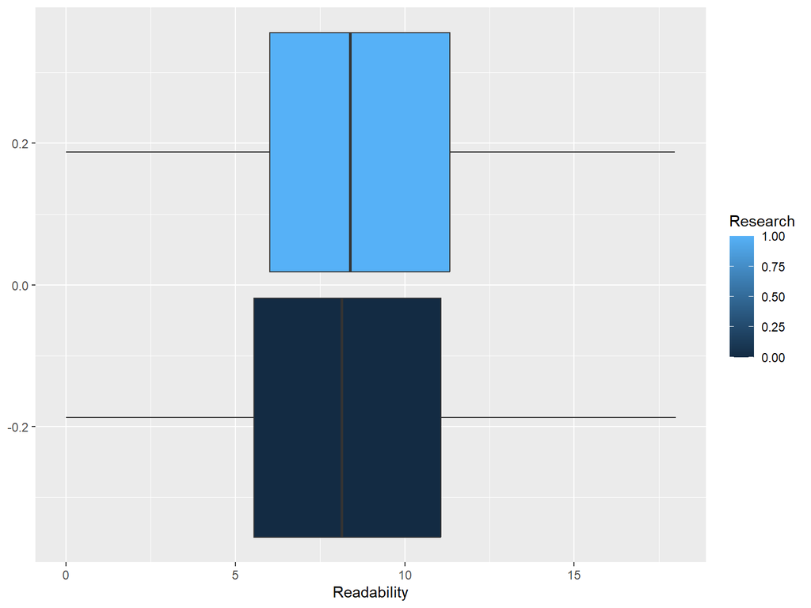

```r
Tweets_User3 %>%
  ggplot(aes(x = Readability, group = Research, fill = Research)) +
  geom_boxplot() +
  xlim(0, 18)
```

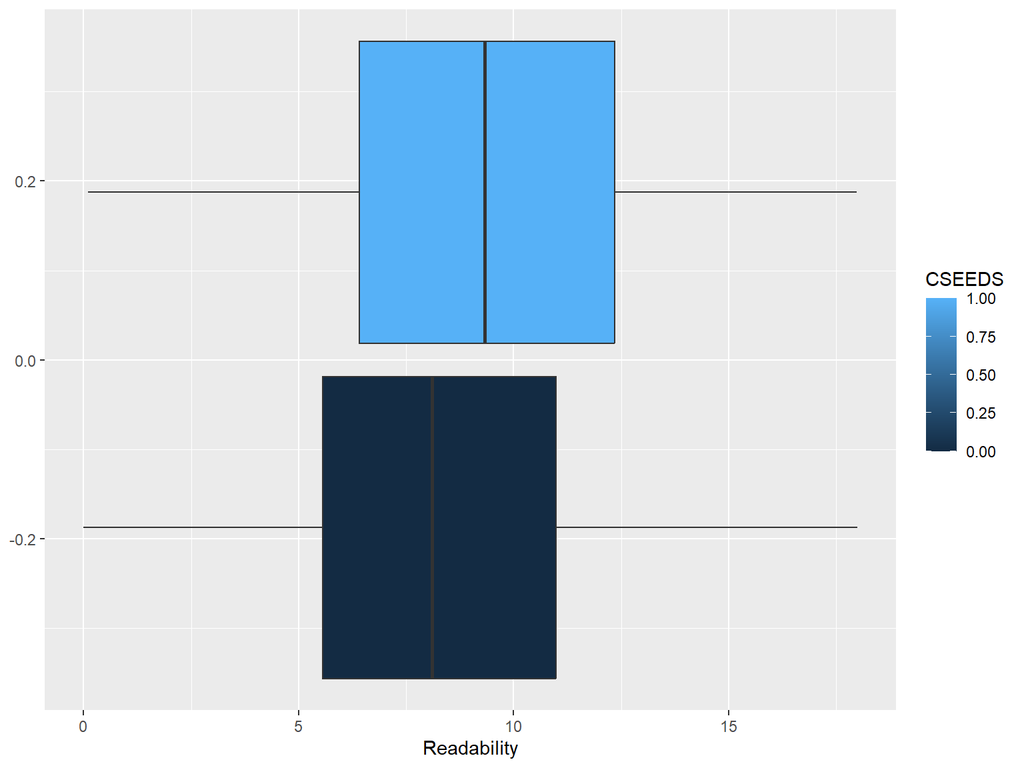

```r
Tweets_User3 %>%
  ggplot(aes(x = Readability, group = CSEEDS, fill = CSEEDS)) +
  geom_boxplot() +
  xlim(0, 18)
```

- 可视化操作：对于文本情感得分

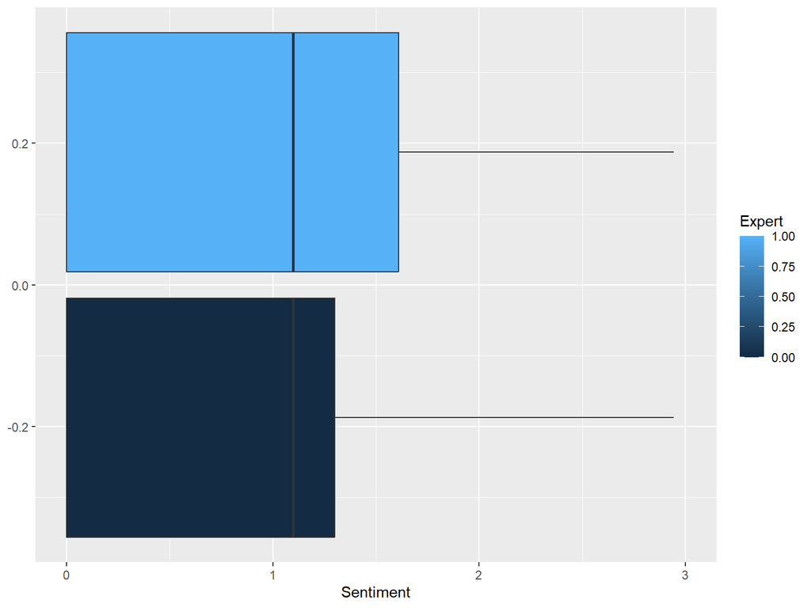

```r
Tweets_User3 %>%
  ggplot(aes(x = Sentiment, group = Expert, fill = Expert)) +
  geom_boxplot() +
  xlim(0, 3)
```

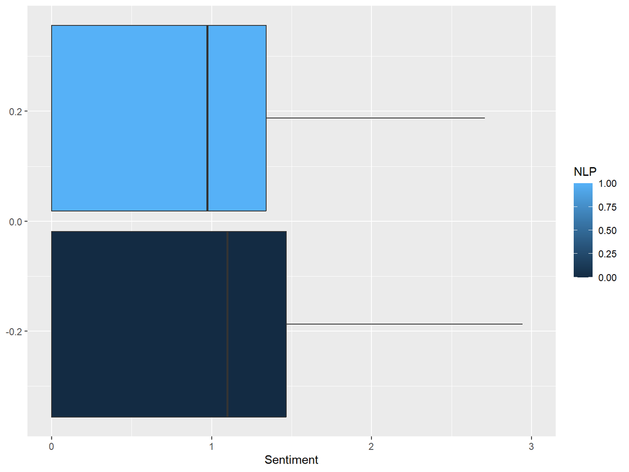

```r
Tweets_User3 %>%
  ggplot(aes(x = Sentiment, group = NLP, fill = NLP)) +
  geom_boxplot() +
  xlim(0, 3)
```

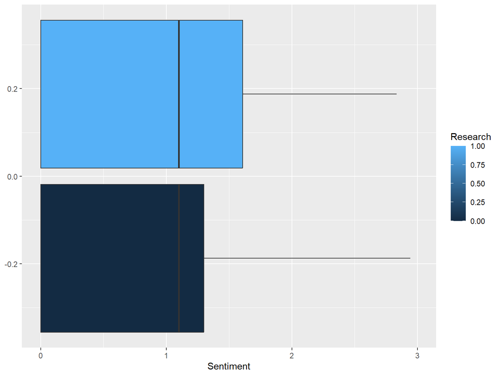

```r
Tweets_User3 %>%
  ggplot(aes(x = Sentiment, group = Research, fill = Research)) +
  geom_boxplot() +
  xlim(0, 3)
```

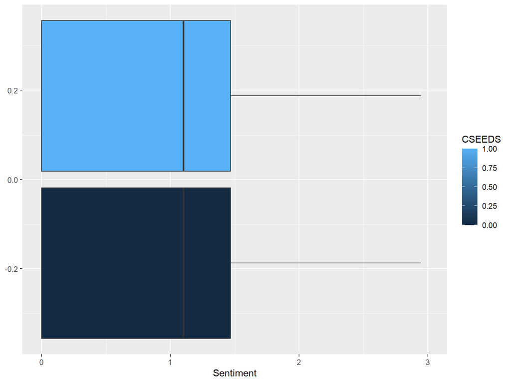

```r
Tweets_User3 %>%
  ggplot(aes(x = Sentiment, group = CSEEDS, fill = CSEEDS)) +
  geom_boxplot() +
  xlim(0, 3)
```

**3. TF-IDF与专家分组(内存不够，做不了)**

# 回归分析

**注意回归分析中各项系数与老师给出的回归系数的差异，还存在许多细微的差异！**

用户层面：UserID, User, UserDescription, WC_Descrip, Relate, NLP, CSEEDS, Research, Location, CreatDate, User_Verified, UserFollowers, UserFriends

推文层面：ID, Tweet, Date, Month, Day_Gap, Likes, LikePerD, Retweets, RetweetPerD, WC, LikeType, RetweetType, MostValuable, readability_Tweet, sentiment_Tweet

```r
Tweets_Reg <- Tweets_User3 %>%
  mutate(
    Followers = log(UserFollowers + 1),
    Friends = log(UserFriends + 1)
    ) %>%
  mutate(
    Sentiment_Test = Sentiment,
    Sentiment = scale(abs(Sentiment), center=F,scale=T)
  ) %>%
  dplyr::select(Most_Popular, Expert, NLP, CSEEDS, Research, User_Verified, Followers, Friends, Day_Gap, Like_Perday, Retweet_Perday, WC, Lexical_Diversity, Readability, Sentiment, Sentiment_Test)
```

**进行回归分析探究**

```r
summary(Tweets_Reg$Sentiment)
```

```
##        V1
##  Min.   :0.0000
##  1st Qu.:0.0000
##  Median :0.9936
##  Mean   :0.7476
##  3rd Qu.:0.9936
##  Max.   :2.9809
```

```r
sd(Tweets_Reg$Sentiment)
```

```
## [1] 0.6641462
```

```r
summary(Tweets_Reg$WC)
```

```
##    Min. 1st Qu.  Median    Mean 3rd Qu.    Max.
##    3.00   13.00   24.00   24.72   36.00   87.00
```

```r
sd(Tweets_Reg$WC)
```

```
## [1] 13.02474
```

```r
summary(Tweets_Reg$Readability)
```

```
##    Min. 1st Qu.  Median    Mean 3rd Qu.    Max.
##  -3.205   5.683   8.413   9.190  11.893  45.750
```

```r
sd(Tweets_Reg$Readability)
```

```
## [1] 5.321282
```

```r
summary(Tweets_Reg$Day_Gap)
```

```
##    Min. 1st Qu.  Median    Mean 3rd Qu.    Max.
##    1.00   17.00   32.00   37.32   54.00   87.00
```

```r
sd(Tweets_Reg$Day_Gap)
```

```
## [1] 24.43919
```

```r
summary(Tweets_Reg$Lexical_Diversity)
```

```
##    Min. 1st Qu.  Median    Mean 3rd Qu.    Max.
##  0.2449  0.8696  0.9268  0.9189  1.0000  1.0000
```

```r
sd(Tweets_Reg$Lexical_Diversity)
```

```
## [1] 0.07570013
```

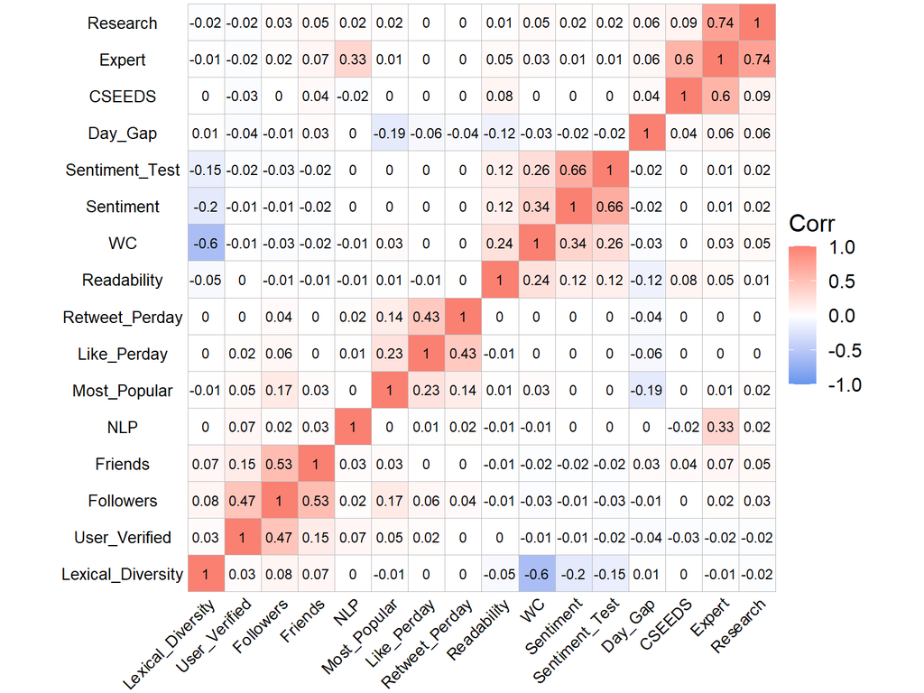

```r
# Model1与2探究可读性以及情感得分与用户特征，但是R2很低

Model_Read1 = lm(Readability~
               Expert +
               User_Verified +
               WC+
               Lexical_Diversity,
              Tweets_Reg)

Model_Read2 = lm(Readability~
               NLP +
               CSEEDS +
               User_Verified +
               WC+
               Lexical_Diversity,
              Tweets_Reg)
```

```r
# 输出规范的三线表
stargazer(list(Model_Read1, Model_Read2),type = "text")
```

```
##
## =============================================================================
##                                        Dependent variable:
##                     ---------------------------------------------------------
##                                            Readability
##                                 (1)                          (2)
## -----------------------------------------------------------------------------
## Expert                        0.742***
##                               (0.066)
##
## NLP                                                        -0.336*
##                                                            (0.181)
##
## CSEEDS                                                     2.108***
##                                                            (0.103)
##
## User_Verified                  -0.104                       -0.062
##                               (0.070)                      (0.071)
##
## WC                            0.136***                     0.136***
##                               (0.002)                      (0.002)
##
## Lexical_Diversity            10.565***                    10.571***
##                               (0.339)                      (0.339)
##
## Constant                     -3.942***                    -3.964***
##                               (0.344)                      (0.343)
##
## -----------------------------------------------------------------------------
## Observations                   62,479                       62,479
## R2                             0.075                        0.080
## Adjusted R2                    0.075                        0.079
## Residual Std. Error      5.117 (df = 62474)           5.105 (df = 62473)
## F Statistic         1,270.147*** (df = 4; 62474) 1,080.045*** (df = 5; 62473)
## =============================================================================
## Note:                                             *p<0.1; **p<0.05; ***p<0.01
```

```r
# Model探究最受欢迎的文本与什么因素有关
Model_Pop1 = glm(Most_Popular~
               Sentiment +
               WC +
               Lexical_Diversity +
               Readability +
               Day_Gap +
               Followers +
               Friends +
               Expert +
               User_Verified,
              Tweets_Reg, family=binomial)

Model_Pop2 = glm(Most_Popular~
               Sentiment +
               WC +
               Lexical_Diversity +
               Readability +
               Day_Gap +
               Followers +
               Friends +
               NLP +
               CSEEDS +
               Research +
               User_Verified,
              Tweets_Reg, family=binomial)
```

```r
# 输出规范的三线表
stargazer(list(Model_Pop1, Model_Pop2),type = "text")
```

```
##
## ==============================================
##                       Dependent variable:
##                   ----------------------------
##                           Most_Popular
##                        (1)            (2)
## ----------------------------------------------
## Sentiment             -0.048        -0.049
##                      (0.030)        (0.030)
##
## WC                   0.014***      0.013***
##                      (0.002)        (0.002)
##
## Lexical_Diversity     -0.156        -0.180
##                      (0.318)        (0.318)
##
## Readability         -0.020***      -0.020***
##                      (0.004)        (0.004)
##
## Day_Gap             -0.056***      -0.056***
##                      (0.001)        (0.001)
##
## Followers            0.397***      0.397***
##                      (0.010)        (0.010)
##
## Friends             -0.092***      -0.092***
##                      (0.009)        (0.009)
##
## Expert               0.363***
##                      (0.059)
##
## NLP                                  0.099
##                                     (0.171)
##
## CSEEDS                              0.185*
##                                     (0.096)
##
## Research                           0.528***
##                                     (0.072)
##
## User_Verified       -0.980***      -0.982***
##                      (0.065)        (0.065)
##
## Constant            -4.003***      -3.978***
##                      (0.328)        (0.329)
##
## ----------------------------------------------
## Observations          62,479        62,479
## Log Likelihood     -10,498.220    -10,487.580
## Akaike Inf. Crit.   21,016.430    20,999.160
## ==============================================
## Note:              *p<0.1; **p<0.05; ***p<0.01
```

```r
# summary(Model3)
```

```r
summary(Model_Pop1)
```

```
##
## Call:
## glm(formula = Most_Popular ~ Sentiment + WC + Lexical_Diversity +
##     Readability + Day_Gap + Followers + Friends + Expert + User_Verified,
##     family = binomial, data = Tweets_Reg)
##
## Deviance Residuals:
##     Min       1Q   Median       3Q      Max
## -1.6577  -0.3452  -0.2036  -0.0999   4.1205
##
## Coefficients:
##                    Estimate Std. Error z value Pr(>|z|)
## (Intercept)       -4.003088   0.328339 -12.192  < 2e-16 ***
## Sentiment         -0.047543   0.030060  -1.582    0.114
## WC                 0.013806   0.001966   7.021 2.20e-12 ***
## Lexical_Diversity -0.156006   0.317543  -0.491    0.623
## Readability       -0.020470   0.003762  -5.441 5.31e-08 ***
## Day_Gap           -0.055944   0.001324 -42.249  < 2e-16 ***
## Followers          0.397294   0.009571  41.510  < 2e-16 ***
## Friends           -0.092283   0.009162 -10.072  < 2e-16 ***
## Expert             0.362751   0.059229   6.125 9.09e-10 ***
## User_Verified     -0.979898   0.064747 -15.134  < 2e-16 ***
## ---
## Signif. codes:  0 '***' 0.001 '**' 0.01 '*' 0.05 '.' 0.1 ' ' 1
##
## (Dispersion parameter for binomial family taken to be 1)
##
##     Null deviance: 25948  on 62478  degrees of freedom
## Residual deviance: 20996  on 62469  degrees of freedom
## AIC: 21016
##
## Number of Fisher Scoring iterations: 7
```

```r
mean(Tweets_Reg$Most_Popular)
```

```
## [1] 0.05313785
```

```r
sd(Tweets_Reg$Most_Popular)
```

```
## [1] 0.2243101
```

```r
# 输出规范的三线表
stargazer(list(Model_Pop1_nb, Model_Pop2_nb),type = "text")
```

```
##
## =========================================================
##                             Dependent variable:
##                   ---------------------------------------
##                                Most_Popular
##                           (1)                 (2)
## ---------------------------------------------------------
## Sentiment               -0.041              -0.042
##                         (0.028)             (0.028)
##
## WC                     0.012***            0.012***
##                         (0.002)             (0.002)
##
## Lexical_Diversity       -0.102              -0.120
##                         (0.293)             (0.293)
##
## Readability            -0.018***           -0.017***
##                         (0.003)             (0.003)
##
## Day_Gap                -0.050***           -0.050***
##                         (0.001)             (0.001)
##
## Followers              0.334***            0.334***
##                         (0.008)             (0.008)
##
## Friends                -0.068***           -0.068***
##                         (0.008)             (0.008)
##
## Expert                 0.320***
##                         (0.055)
##
## NLP                                          0.099
##                                             (0.160)
##
## CSEEDS                                      0.166*
##                                             (0.089)
##
## Research                                   0.455***
##                                             (0.065)
##
## User_Verified          -0.852***           -0.854***
##                         (0.059)             (0.059)
##
## Constant               -3.924***           -3.904***
##                         (0.304)             (0.304)
##
## ---------------------------------------------------------
## Observations            62,479              62,479
## Log Likelihood        -10,800.800         -10,791.630
## theta             243.294*** (91.531) 243.708*** (91.667)
## Akaike Inf. Crit.     21,621.590          21,607.250
## =========================================================
## Note:                         *p<0.1; **p<0.05; ***p<0.01
```

```r
# summary(Model3)
```

```r
# Model3探究最受欢迎的文本与什么因素有关
Model_Pop3 = glm(Most_Popular~
               Sentiment_Test +
               WC +
               Lexical_Diversity +
               Readability +
               Day_Gap +
               Followers +
               Friends +
               Expert +
               User_Verified,
              Tweets_Reg, family=binomial)

Model_Pop4 = glm(Most_Popular~
               Sentiment_Test +
               WC +
               Lexical_Diversity +
               Readability +
               Day_Gap +
               Followers +
               Friends +
               NLP +
               CSEEDS +
               Research +
               User_Verified,
              Tweets_Reg, family=binomial)

Model_Pop5 = glm(Most_Popular~
               Sentiment_Test +
               WC +
               Lexical_Diversity +
               Readability +
               Day_Gap +
               Followers +
               Friends +
               User_Verified,
              Tweets_Reg, family=binomial)
```

```r
# 输出规范的三线表
stargazer(list(Model_Pop3, Model_Pop4, Model_Pop5),type = "text")
```

```
##
## =====================================================
##                           Dependent variable:
##                   -----------------------------------
##                              Most_Popular
##                       (1)         (2)         (3)
## -----------------------------------------------------
## Sentiment_Test      -0.033      -0.034*     -0.034*
##                     (0.020)     (0.020)     (0.020)
##
## WC                 0.014***    0.013***    0.014***
##                     (0.002)     (0.002)     (0.002)
##
## Lexical_Diversity   -0.150      -0.173      -0.169
##                     (0.318)     (0.318)     (0.317)
##
## Readability        -0.020***   -0.020***   -0.019***
##                     (0.004)     (0.004)     (0.004)
##
## Day_Gap            -0.056***   -0.056***   -0.056***
##                     (0.001)     (0.001)     (0.001)
##
## Followers          0.397***    0.397***    0.394***
##                     (0.010)     (0.010)     (0.010)
##
## Friends            -0.092***   -0.092***   -0.087***
##                     (0.009)     (0.009)     (0.009)
##
## Expert             0.363***
##                     (0.059)
##
## NLP                              0.101
##                                 (0.171)
##
## CSEEDS                          0.186*
##                                 (0.096)
##
## Research                       0.529***
##                                 (0.072)
##
## User_Verified      -0.980***   -0.982***   -0.981***
##                     (0.065)     (0.065)     (0.065)
##
## Constant           -4.022***   -3.997***   -3.983***
##                     (0.328)     (0.328)     (0.328)
##
## -----------------------------------------------------
## Observations        62,479      62,479      62,479
## Log Likelihood    -10,498.170 -10,487.530 -10,515.810
## Akaike Inf. Crit. 21,016.350  20,999.060  21,049.620
## =====================================================
## Note:                     *p<0.1; **p<0.05; ***p<0.01
```

```r
# summary(Model3)
```